# delMazo-finger4

Utilizando las herramientas que proveen distintas bibliotecas de Python (Numpy, Sklearn, etc.), se quiere realizar un análisis sobre reducción de dimensiones y visualización de datos. Se utilizará un set de datos sobre el cual se puede analizar la relación entre distintas muestras de tejido en términos de expresión genética.

El primer archivo contiene 1641 observaciones, y el segundo archivo contiene para cada una de esas observaciones su label correspondiente respetando el orden de los registros. Es decir, por ejemplo, el label del primer registro de GTExdata.csv es el primer registro del archivo SampleLabels.csv y así sucesivamente. El label que vamos a usar es Tissue type.

Se plantean los siguientes puntos a realizar:

1) Realizar una descomposición en valores singulares sobre el set y luego:

- Graficar la energía acumulada en función de la cantidad de autovalores, y graficar los autovalores del set.
- Con los dos gráficos anteriores, indicar qué valor de k se podría utilizar para realizar una aproximación.
- Realizar una reducción a dos dimensiones del set de datos y graficar los puntos en un scatter-plot utilizando colores para indicar el label correspondiente a cada punto.

2) Utilizando el algoritmo t-SNE, se pide:

- Realizar un scatter-plot en el plano 2D, utilizando colores para indicar el label.
- Probar varios valores de perplexity (e.g. 3, 30, 1000). ¿Qué efectos tiene el perplexity en el gráfico?

```python
import numpy as np
import matplotlib.pyplot as plt
import seaborn as sns
import pandas as pd
from scipy.linalg import svd
from sklearn.manifold import TSNE
```

```python
sns.set(style="darkgrid")
plt.rcParams['figure.figsize'] = (25,15)
```

```python
df_gtex = pd.read_csv('GTExdata.csv',low_memory=False)
display(df_gtex.head())

df_sample = pd.read_csv('SampleLabels.csv',low_memory=False)
display(df_sample.head())

# Solo nos importa 'Tissue Type'
df_sample = df_sample[['Tissue type']]
```

|  | -0.81443 | -0.1728 | -0.13566 | 4.036 | 3.4742 | 0.017055 | 0.76495 | 3.0281 | 0.56595 | 1.9045 | ... | -0.88508 | -2.2228 | -3.0385 | -2.8584 | -3.4724 | -2.5374 | -2.9705 | -1.8397 | -2.1044 | -1.9881 |
| --- | --- | --- | --- | --- | --- | --- | --- | --- | --- | --- | --- | --- | --- | --- | --- | --- | --- | --- | --- | --- | --- |
| 0 | -1.219500 | -0.139670 | -0.217330 | -1.4361 | -0.86158 | 0.403280 | -0.91309 | 6.9136 | 4.38540 | 6.15440 | ... | 2.01310 | 1.25060 | 0.333560 | 0.37651 | -0.086984 | 0.221580 | 1.205700 | 0.81913 | 0.20093 | 1.371100 |
| 1 | -0.010044 | -0.042155 | 0.111440 | -1.0768 | -0.72246 | 0.651900 | -0.79763 | 5.6678 | 2.94680 | 4.63420 | ... | -1.07800 | -0.52936 | -0.989140 | -3.10870 | -3.262500 | -1.159200 | 0.091823 | -1.14740 | -1.59540 | -0.092996 |
| 2 | -1.336400 | -0.088622 | -0.126460 | -1.7866 | -0.99562 | 0.009797 | -1.05550 | 6.5985 | 4.22730 | 6.02260 | ... | 0.67228 | 0.98691 | 0.142270 | 0.34028 | -0.129170 | 0.064783 | 1.279200 | 1.05850 | 0.63342 | 1.581000 |
| 3 | -1.055100 | -0.065230 | -0.087368 | -1.4559 | -0.69961 | 0.205960 | -0.83905 | 6.1986 | 4.05600 | 5.78430 | ... | 0.48401 | 0.63014 | 0.061371 | -0.82861 | -1.537200 | -0.121850 | 0.735520 | 0.32366 | -0.54558 | 0.789580 |
| 4 | -0.538700 | -0.184340 | -0.266680 | -1.8266 | -0.79040 | 0.593780 | -0.79899 | -1.7453 | -0.25312 | -0.47961 | ... | -0.22813 | 1.03090 | 1.608100 | 1.59950 | 1.478600 | 2.137100 | 0.563560 | 0.11520 | -0.21623 | 0.675090 |

5 rows × 16142 columns

|  | Sampleid | Tissue type specific | Tissue type |
| --- | --- | --- | --- |
| 0 | GTEX-N7MS-0007-SM-2D7W1 | Whole Blood | Blood |
| 1 | GTEX-N7MS-0011-R10A-SM-2HMJK | Brain - Frontal Cortex (BA9) | Brain |
| 2 | GTEX-N7MS-0011-R11A-SM-2HMJS | Brain - Cerebellar Hemisphere | Brain |
| 3 | GTEX-N7MS-0011-R1a-SM-2HMJG | Brain - Hippocampus | Brain |
| 4 | GTEX-N7MS-0011-R2a-SM-2HML6 | Brain - Substantia nigra | Brain |

1) Realizar una descomposición en valores singulares sobre el set y luego:

- Graficar la energía acumulada en función de la cantidad de autovalores, y graficar los autovalores del set.
- Con los dos gráficos anteriores, indicar qué valor de k se podría utilizar para realizar una aproximación.
- Realizar una reducción a dos dimensiones del set de datos y graficar los puntos en un scatter-plot utilizando colores para indicar el label correspondiente a cada punto.

```python
u, s, vt = svd(df_gtex)
display(u[:3],s[:3],vt[:3])
```

```
array([[-0.00703632, -0.05159181, -0.02688277, ..., -0.01438146,
         0.02250871,  0.02506192],
       [-0.01036805, -0.04717453, -0.03237933, ...,  0.00655914,
         0.00481917,  0.02418323],
       [-0.0061543 , -0.04945944, -0.02910699, ..., -0.00251176,
        -0.04036477,  0.02479664]])
```

```
array([2529.42267308, 2153.50881001, 1857.28127452])
```

```
array([[-0.00272671,  0.00031285, -0.0002712 , ..., -0.00893846,
        -0.00649791, -0.01029521],
       [ 0.00471399,  0.00118774,  0.00116537, ..., -0.01130399,
        -0.00891344, -0.01319021],
       [-0.00521128, -0.00179898, -0.00183147, ...,  0.00957051,
         0.01157811,  0.00950642]])
```

```python
energia_total = sum(s**2)
autovalores_al_cuadrado = s**2
energia_acumulada = np.cumsum(autovalores_al_cuadrado)

energia_acumulada[:3]
```

```
array([ 6397979.05909114, 11035579.25388481, 14485072.98656284])
```

```
Text(0,0.5,'Valor')
```

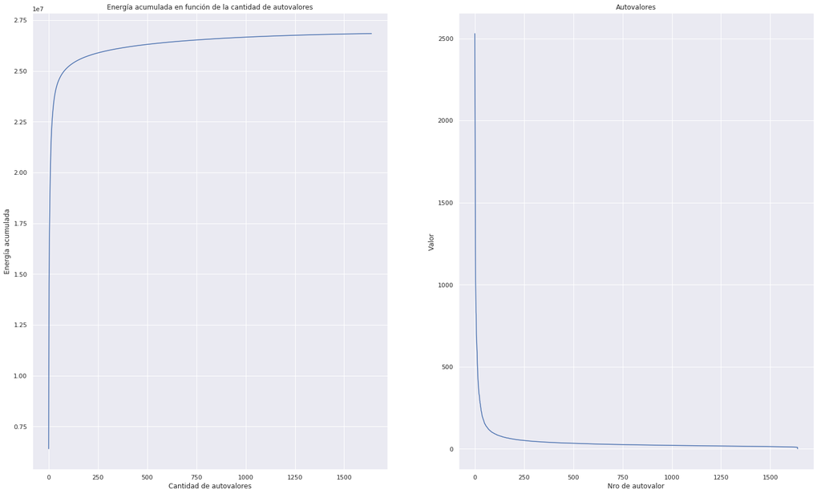

```python
plt.subplot(1,2,1)
plt.plot(energia_acumulada)
plt.title('Energía acumulada en función de la cantidad de autovalores')
plt.xlabel('Cantidad de autovalores')
plt.ylabel('Energía acumulada')

plt.subplot(1,2,2)
plt.plot(s)
plt.title('Autovalores')
plt.xlabel('Nro de autovalor')
plt.ylabel('Valor')
```

Podemos ver que los primeros 250 autovalores son los que contienen la mayor parte de la información, o incluso menos que esto. Busquemos el codo dentro de estos

```
Text(0,0.5,'Energía acumulada en porcentaje')
```

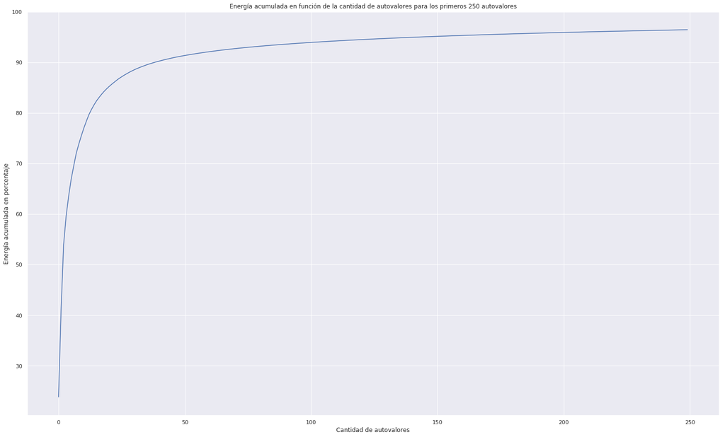

```python
porcentaje = ((autovalores_al_cuadrado / energia_total) * 100)
porcentaje_acumulado = np.cumsum(porcentaje)

primeros_250 = porcentaje_acumulado[:250]
plt.plot(primeros_250)

plt.title('Energía acumulada en función de la cantidad de autovalores para los primeros 250 autovalores')
plt.xlabel('Cantidad de autovalores')
plt.ylabel('Energía acumulada en porcentaje')
```

Hacemos un zoom mas

```
Text(0,0.5,'Energía acumulada en porcentaje')
```

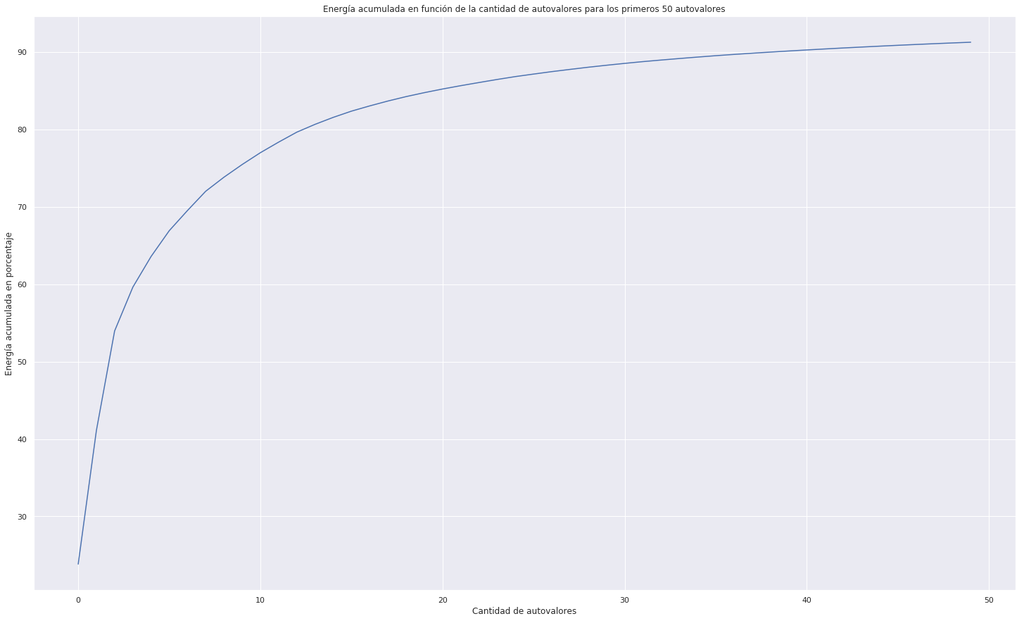

```python
primeros_50 = porcentaje_acumulado[:50]
plt.plot(primeros_50)

plt.title('Energía acumulada en función de la cantidad de autovalores para los primeros 50 autovalores')
plt.xlabel('Cantidad de autovalores')
plt.ylabel('Energía acumulada en porcentaje')
```

```python
print('Con k=10 se preserva un {:.2f}% de la información'.format(porcentaje_acumulado[10]))
print('Con k=20 se preserva un {:.2f}% de la información'.format(porcentaje_acumulado[20]))
print('Con k=30 se preserva un {:.2f}% de la información'.format(porcentaje_acumulado[30]))
print('Con k=40 se preserva un {:.2f}% de la información'.format(porcentaje_acumulado[40]))
print('Con k=50 se preserva un {:.2f}% de la información'.format(porcentaje_acumulado[50]))
```

```
Con k=10 se preserva un 76.99% de la información
Con k=20 se preserva un 85.22% de la información
Con k=30 se preserva un 88.53% de la información
Con k=40 se preserva un 90.27% de la información
Con k=50 se preserva un 91.36% de la información
```

Se concluye que se puede usars un K entre 40 y 50.

```python
# Realizo el producto interno entre U y Sigma y sobre el resultado me quedo con las dos primeras columnas

reduccion_k_2 = u * s
reduccion_k_2 = np.matrix(reduccion_k_2)[:,:2]
reduccion_k_2 = pd.DataFrame(reduccion_k_2)
reduccion_k_2 = reduccion_k_2.merge(df_sample, left_index=True, right_index=True)
reduccion_k_2.head()
```

|  | 0 | 1 | Tissue type |
| --- | --- | --- | --- |
| 0 | -17.797830 | -111.103408 | Blood |
| 1 | -26.225187 | -101.590768 | Brain |
| 2 | -15.566838 | -106.511350 | Brain |
| 3 | -20.078743 | -91.136776 | Brain |
| 4 | -18.780981 | -115.087913 | Brain |

```
Text(0.5,1,'Información reducida a 2 dimensiones')
```

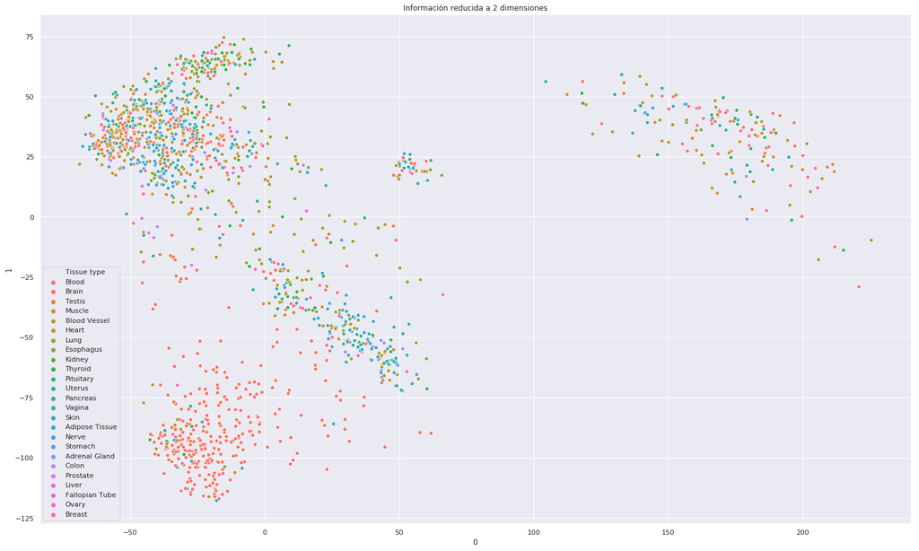

```python
sns.scatterplot(0,1,data=reduccion_k_2,hue='Tissue type')
plt.title('Información reducida a 2 dimensiones')
```

2) Utilizando el algoritmo t-SNE, se pide:

- Realizar un scatter-plot en el plano 2D, utilizando colores para indicar el label.
- Probar varios valores de perplexity (e.g. 3, 30, 1000). ¿Qué efectos tiene el perplexity en el gráfico?

```
[t-SNE] Computing 91 nearest neighbors...
[t-SNE] Indexed 1640 samples in 3.936s...
[t-SNE] Computed neighbors for 1640 samples in 197.933s...
[t-SNE] Computed conditional probabilities for sample 1000 / 1640
[t-SNE] Computed conditional probabilities for sample 1640 / 1640
[t-SNE] Mean sigma: 22.731142
[t-SNE] KL divergence after 250 iterations with early exaggeration: 53.430653
[t-SNE] Error after 1000 iterations: 0.524922
```

```
Text(0.5,1,'TSNE con todos los datos')
```

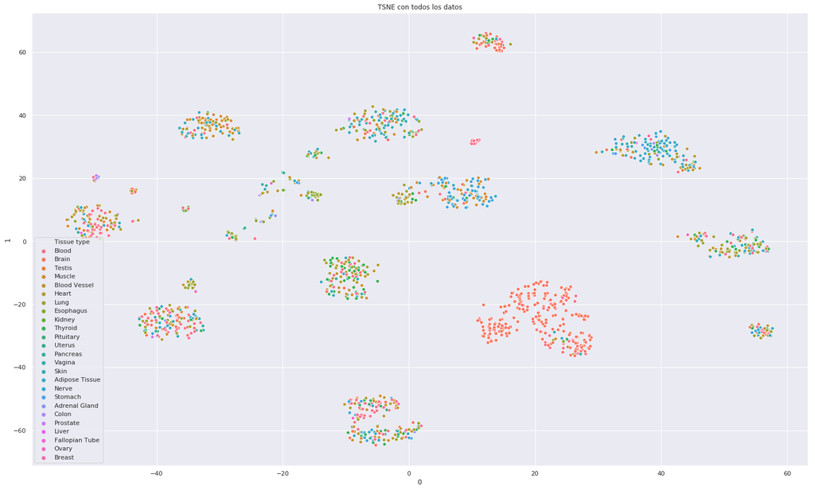

```python
tsne = TSNE(n_components=2, verbose=1)
tsne_resultado = tsne.fit_transform(df_gtex)
df_tsne = pd.DataFrame(tsne_resultado)
df_tsne = df_tsne.merge(df_sample, left_index=True, right_index=True)

sns.scatterplot(x=0,y=1,data=df_tsne,hue='Tissue type')
plt.title('TSNE con todos los datos')
```

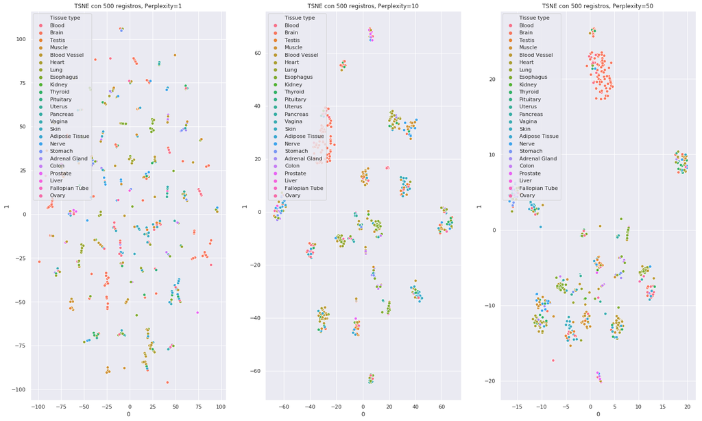

```python
perplexities = [1,10,50]
seleccion = 500

fig, axs = plt.subplots(ncols=len(perplexities))

for i,p in enumerate(perplexities):
    tsne = TSNE(n_components=2,perplexity=p)
    tsne_resultado = tsne.fit_transform(df_gtex[:seleccion])
    df_tsne = pd.DataFrame(tsne_resultado)
    df_tsne = df_tsne.merge(df_sample, left_index=True, right_index=True)
    sns.scatterplot(x=0,y=1,data=df_tsne,hue='Tissue type',ax=axs[i])
    axs[i].set_title('TSNE con {} registros, Perplexity={}'.format(seleccion, p))
```

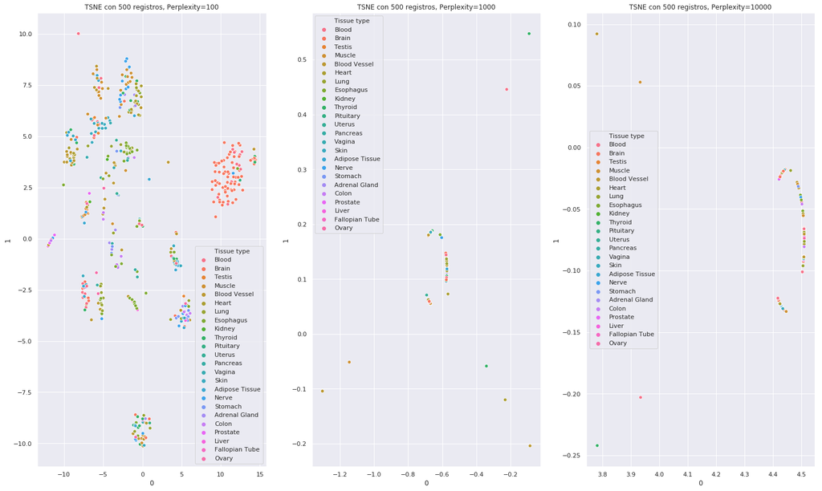

```python
perplexities = [100,1000,10000]
seleccion = 500

fig, axs = plt.subplots(ncols=len(perplexities))

for i,p in enumerate(perplexities):
    tsne = TSNE(n_components=2,perplexity=p)
    tsne_resultado = tsne.fit_transform(df_gtex[:seleccion])
    df_tsne = pd.DataFrame(tsne_resultado)
    df_tsne = df_tsne.merge(df_sample, left_index=True, right_index=True)
    sns.scatterplot(x=0,y=1,data=df_tsne,hue='Tissue type',ax=axs[i])
    axs[i].set_title('TSNE con {} registros, Perplexity={}'.format(seleccion, p))
```

Se puede ver como la variable de la perplejidad modifica como se agrupan los datos. A menor perplejidad, más grupos se formaran, aislandose del resto, mientras que a mayor todo será parte de la misma gran nube.